# Final Project Report

Oshika Mishra and Evan Spinney

Due: 12-16-21

### Data Access

For our project, we decided to research movies and TV shows in the media to discover how different streaming platforms recommend new films for viewers to watch. It is unlikely that we would genuinely figure out how it’s accomplished by each platform because each platform has their own unique algorithm they use that are specific to each user. The algorithm itself takes into account the newest and most popular shows and movies when the viewers use the site as well as each and every user’s watch history. The sites generally have a few sections such as “Because you watched. . .” and “You might like. . .” where it shows other films or shows that have not been watched yet, but the user may like based on what they have already watched. As to how the algorithm works, we pretty much know what it does, and a little bit about how it works, we just don’t know how it works in terms of each user, and we don’t know why certain shows and movies are suggested to users over another with similar characteristics. With this project, we have found two data sources that may be able to help us answer those questions. Both tables have a large assortment of movies over the years with plenty of variables to go along with them including genre, popularity, runtime, director, release date, and more. This variables have an influence on popularity and, naturally, revenue for each film or show and for the streaming platform. In terms of number of users, as of 2021, YouTube is the most used streaming platform which is primarily used for personal videos that people make and share with others for a number of purposes. The second highest is Netflix with roughly 195 million users followed by Amazon Prime and then Disney+ which only contain movies and TV shows. All of these have their own way of suggesting new content for the users of these sites, and we are going to look at what components of movies make certain ones more suggestable over another to the users. With our data, and the number of variables provided for the movies and shows in our tables, we should hopefully be able to successfully answer that question.

```r
# clean up workspace environment
rm(list = ls())
# all packages used for the assignment
library(mosaic)
library(tidyverse)
library(dcData)
library(hexView)
library(dplyr)
library(tidyr)
```

## First Source

```r
MetaData <- read.csv('metadata.csv')
MetaData %>%
  summary(MetaData)
```

```
    adult           belongs_to_collection    budget
 Length:45466       Length:45466          Length:45466
 Class :character   Class :character      Class :character
 Mode  :character   Mode  :character      Mode  :character




    genres            homepage              id
 Length:45466       Length:45466       Length:45466
 Class :character   Class :character   Class :character
 Mode  :character   Mode  :character   Mode  :character




   imdb_id          original_language  original_title
 Length:45466       Length:45466       Length:45466
 Class :character   Class :character   Class :character
 Mode  :character   Mode  :character   Mode  :character




   overview          popularity        poster_path
 Length:45466       Length:45466       Length:45466
 Class :character   Class :character   Class :character
 Mode  :character   Mode  :character   Mode  :character




 production_companies production_countries release_date
 Length:45466         Length:45466         Length:45466
 Class :character     Class :character     Class :character
 Mode  :character     Mode  :character     Mode  :character




```

[output cut: 9 more lines]

```
 Length:45466       Length:45466       Length:45466       Mode :logical
 Class :character   Class :character   Class :character   FALSE:45367
 Mode  :character   Mode  :character   Mode  :character   TRUE :93
                                                          NA's :6



  vote_average      vote_count
 Min.   : 0.000   Min.   :    0.0
 1st Qu.: 5.000   1st Qu.:    3.0
 Median : 6.000   Median :   10.0
 Mean   : 5.618   Mean   :  109.9
 3rd Qu.: 6.800   3rd Qu.:   34.0
 Max.   :10.000   Max.   :14075.0
 NA's   :6        NA's   :6
```

This is our primary data set that we found for the project. As shown, there are a substantial number of variables from this table alone that could help us answer our research question. This was the table we obtained from Kaggle, and it contains critical variables like the genre, runtime, budget, revenue and more, and at the same time, it also contains fairly unique variables such as production company, production country, and the language the film is in. All of those are unique but resourceful information we can utilize to answer any and all questions branched from our main research question.

```r
MetaData%>%
  head(5)
```

|  | adult | belongs_to_collection | budget | genres | homepage | id | imdb_id | original_language | original_title | overview | popularity | poster_path | production_companies | production_countries | release_date | revenue | runtime | spoken_languages | status | tagline | title | video | vote_average | vote_count |
| --- | --- | --- | --- | --- | --- | --- | --- | --- | --- | --- | --- | --- | --- | --- | --- | --- | --- | --- | --- | --- | --- | --- | --- | --- |
| 1 | FALSE | {'id': 10194, 'name': 'Toy Story Collection', 'poster_path': '/7G9915LfUQ2lVfwMEEhDsn3kT4B.jpg', 'backdrop_path': '/9FBwqcd9IRruEDUrTdcaafOMKUq.jpg'} | 30000000 | [{'id': 16, 'name': 'Animation'}, {'id': 35, 'name': 'Comedy'}, {'id': 10751, 'name': 'Family'}] | http://toystory.disney.com/toy-story | 862 | tt0114709 | en | Toy Story | Led by Woody, Andy's toys live happily in his room until Andy's birthday brings Buzz Lightyear onto the scene. Afraid of losing his place in Andy's heart, Woody plots against Buzz. But when circumstan… | 21.946943 | /rhIRbceoE9lR4veEXuwCC2wARtG.jpg | [{'name': 'Pixar Animation Studios', 'id': 3}] | [{'iso_3166_1': 'US', 'name': 'United States of America'}] | 10/30/1995 | 373554033 | 81 | [{'iso_639_1': 'en', 'name': 'English'}] | Released |  | Toy Story | FALSE | 7.7 | 5415 |
| 2 | FALSE |  | 65000000 | [{'id': 12, 'name': 'Adventure'}, {'id': 14, 'name': 'Fantasy'}, {'id': 10751, 'name': 'Family'}] |  | 8844 | tt0113497 | en | Jumanji | When siblings Judy and Peter discover an enchanted board game that opens the door to a magical world, they unwittingly invite Alan -- an adult who's been trapped inside the game for 26 years -- into t… | 17.015539 | /vzmL6fP7aPKNKPRTFnZmiUfciyV.jpg | [{'name': 'TriStar Pictures', 'id': 559}, {'name': 'Teitler Film', 'id': 2550}, {'name': 'Interscope Communications', 'id': 10201}] | [{'iso_3166_1': 'US', 'name': 'United States of America'}] | 12/15/1995 | 262797249 | 104 | [{'iso_639_1': 'en', 'name': 'English'}, {'iso_639_1': 'fr', 'name': 'Français'}] | Released | Roll the dice and unleash the excitement! | Jumanji | FALSE | 6.9 | 2413 |
| 3 | FALSE | {'id': 119050, 'name': 'Grumpy Old Men Collection', 'poster_path': '/nLvUdqgPgm3F85NMCii9gVFUcet.jpg', 'backdrop_path': '/hypTnLot2z8wpFS7qwsQHW1uV8u.jpg'} | 0 | [{'id': 10749, 'name': 'Romance'}, {'id': 35, 'name': 'Comedy'}] |  | 15602 | tt0113228 | en | Grumpier Old Men | A family wedding reignites the ancient feud between next-door neighbors and fishing buddies John and Max. Meanwhile, a sultry Italian divorcée opens a restaurant at the local bait shop, alarming the … | 11.7129 | /6ksm1sjKMFLbO7UY2i6G1ju9SML.jpg | [{'name': 'Warner Bros.', 'id': 6194}, {'name': 'Lancaster Gate', 'id': 19464}] | [{'iso_3166_1': 'US', 'name': 'United States of America'}] | 12/22/1995 | 0 | 101 | [{'iso_639_1': 'en', 'name': 'English'}] | Released | Still Yelling. Still Fighting. Still Ready for Love. | Grumpier Old Men | FALSE | 6.5 | 92 |
| 4 | FALSE |  | 16000000 | [{'id': 35, 'name': 'Comedy'}, {'id': 18, 'name': 'Drama'}, {'id': 10749, 'name': 'Romance'}] |  | 31357 | tt0114885 | en | Waiting to Exhale | Cheated on, mistreated and stepped on, the women are holding their breath, waiting for the elusive "good man" to break a string of less-than-stellar lovers. Friends and confidants Vannah, Bernie, Glo … | 3.859495 | /16XOMpEaLWkrcPqSQqhTmeJuqQl.jpg | [{'name': 'Twentieth Century Fox Film Corporation', 'id': 306}] | [{'iso_3166_1': 'US', 'name': 'United States of America'}] | 12/22/1995 | 81452156 | 127 | [{'iso_639_1': 'en', 'name': 'English'}] | Released | Friends are the people who let you be yourself... and never let you forget it. | Waiting to Exhale | FALSE | 6.1 | 34 |
| 5 | FALSE | {'id': 96871, 'name': 'Father of the Bride Collection', 'poster_path': '/nts4iOmNnq7GNicycMJ9pSAn204.jpg', 'backdrop_path': '/7qwE57OVZmMJChBpLEbJEmzUydk.jpg'} | 0 | [{'id': 35, 'name': 'Comedy'}] |  | 11862 | tt0113041 | en | Father of the Bride Part II | Just when George Banks has recovered from his daughter's wedding, he receives the news that she's pregnant ... and that George's wife, Nina, is expecting too. He was planning on selling their home, bu… | 8.387519 | /e64sOI48hQXyru7naBFyssKFxVd.jpg | [{'name': 'Sandollar Productions', 'id': 5842}, {'name': 'Touchstone Pictures', 'id': 9195}] | [{'iso_3166_1': 'US', 'name': 'United States of America'}] | 2/10/1995 | 76578911 | 106 | [{'iso_639_1': 'en', 'name': 'English'}] | Released | Just When His World Is Back To Normal... He's In For The Surprise Of His Life! | Father of the Bride Part II | FALSE | 5.7 | 173 |

## Second Source

```r
IMDbMovies <- read.csv('Imdbmovies.csv')
IMDbMovies %>%
  summary(IMDbMovies)
```

```
 imdb_title_id         title           original_title
 Length:85855       Length:85855       Length:85855
 Class :character   Class :character   Class :character
 Mode  :character   Mode  :character   Mode  :character




     year           date_published        genre              duration
 Length:85855       Length:85855       Length:85855       Min.   : 41.0
 Class :character   Class :character   Class :character   1st Qu.: 88.0
 Mode  :character   Mode  :character   Mode  :character   Median : 96.0
                                                          Mean   :100.4
                                                          3rd Qu.:108.0
                                                          Max.   :808.0

   country            language           director
 Length:85855       Length:85855       Length:85855
 Class :character   Class :character   Class :character
 Mode  :character   Mode  :character   Mode  :character




    writer          production_company    actors
 Length:85855       Length:85855       Length:85855
 Class :character   Class :character   Class :character
 Mode  :character   Mode  :character   Mode  :character




 description           avg_vote         votes            budget
 Length:85855       Min.   :1.000   Min.   :     99   Length:85855
 Class :character   1st Qu.:5.200   1st Qu.:    205   Class :character
 Mode  :character   Median :6.100   Median :    484   Mode  :character
                    Mean   :5.899   Mean   :   9494
                    3rd Qu.:6.800   3rd Qu.:   1766
                    Max.   :9.900   Max.   :2278845

 usa_gross_income   worlwide_gross_income   metascore
 Length:85855       Length:85855          Min.   :  1.0
 Class :character   Class :character      1st Qu.: 43.0
 Mode  :character   Mode  :character      Median : 57.0
                                          Mean   : 55.9
                                          3rd Qu.: 69.0
                                          Max.   :100.0
                                          NA's   :72550
 reviews_from_users reviews_from_critics
 Min.   :    1.00   Min.   :  1.00
 1st Qu.:    4.00   1st Qu.:  3.00
 Median :    9.00   Median :  8.00
 Mean   :   46.04   Mean   : 27.48
 3rd Qu.:   27.00   3rd Qu.: 23.00
 Max.   :10472.00   Max.   :999.00
 NA's   :7597       NA's   :11797
```

This second table was the one found that we do not know much about the creator. Our second table has a significantly larger amount of data available for us, so most of our findings will likely be found from this table which also contains unique variables that can very well be beneficial for us in our research. It contains variables such as writer, director, language, and more. Some of the variables are the same in the first table like title and genre, as well as the duration of the movie or film even though the first tables column for that is called “Runtime.”

```r
IMDbMovies %>%
  head(5)
```

|  | imdb_title_id | title | original_title | year | date_published | genre | duration | country | language | director | writer | production_company | actors | description | avg_vote | votes | budget | usa_gross_income | worlwide_gross_income | metascore | reviews_from_users | reviews_from_critics |
| --- | --- | --- | --- | --- | --- | --- | --- | --- | --- | --- | --- | --- | --- | --- | --- | --- | --- | --- | --- | --- | --- | --- |
| 1 | tt0000009 | Miss Jerry | Miss Jerry | 1894 | 1894-10-09 | Romance | 45 | USA | None | Alexander Black | Alexander Black | Alexander Black Photoplays | Blanche Bayliss, William Courtenay, Chauncey Depew | The adventures of a female reporter in the 1890s. | 5.9 | 154 |  |  |  | NA | 1 | 2 |
| 2 | tt0000574 | The Story of the Kelly Gang | The Story of the Kelly Gang | 1906 | 12/26/1906 | Biography, Crime, Drama | 70 | Australia | None | Charles Tait | Charles Tait | J. and N. Tait | Elizabeth Tait, John Tait, Norman Campbell, Bella Cola, Will Coyne, Sam Crewes, Jack Ennis, John Forde, Vera Linden, Mr. Marshall, Mr. McKenzie, Frank Mills, Ollie Wilson | True story of notorious Australian outlaw Ned Kelly (1855-80). | 6.1 | 589 | $2,250 |  |  | NA | 7 | 7 |
| 3 | tt0001892 | Den sorte drøm | Den sorte drøm | 1911 | 8/19/1911 | Drama | 53 | Germany, Denmark |  | Urban Gad | Urban Gad, Gebhard Schätzler-Perasini | Fotorama | Asta Nielsen, Valdemar Psilander, Gunnar Helsengreen, Emil Albes, Hugo Flink, Mary Hagen | Two men of high rank are both wooing the beautiful and famous equestrian acrobat Stella. While Stella ignores the jeweler Hirsch, she accepts Count von Waldberg's offer to follow her home, ... | 5.8 | 188 |  |  |  | NA | 5 | 2 |
| 4 | tt0002101 | Cleopatra | Cleopatra | 1912 | 11/13/1912 | Drama, History | 100 | USA | English | Charles L. Gaskill | Victorien Sardou | Helen Gardner Picture Players | Helen Gardner, Pearl Sindelar, Miss Fielding, Miss Robson, Helene Costello, Charles Sindelar, Mr. Howard, James R. Waite, Mr. Osborne, Harry Knowles, Mr. Paul, Mr. Brady, Mr. Corker | The fabled queen of Egypt's affair with Roman general Marc Antony is ultimately disastrous for both of them. | 5.2 | 446 | $45,000 |  |  | NA | 25 | 3 |
| 5 | tt0002130 | L'Inferno | L'Inferno | 1911 | 3/6/1911 | Adventure, Drama, Fantasy | 68 | Italy | Italian | Francesco Bertolini, Adolfo Padovan | Dante Alighieri | Milano Film | Salvatore Papa, Arturo Pirovano, Giuseppe de Liguoro, Pier Delle Vigne, Augusto Milla, Attilio Motta, Emilise Beretta | Loosely adapted from Dante's Divine Comedy and inspired by the illustrations of Gustav Doré the original silent film has been restored and has a new score by Tangerine Dream. | 7.0 | 2237 |  |  |  | NA | 31 | 14 |

With one table containing over 45,000 units of observation, and the other almost double that, the tables should have matching cases, and plenty of unique cases as there are a handful of them that were produced and released in other countries with titles in another language. Even if they don’t have that many matches, we will definitely still make some observations from the data we’ve gathered.

### Data Wrangling / Cleaning

```r
Joined_inner <-
  IMDbMovies %>%
  inner_join(MetaData)
Joined_inner
```

| imdb_title_id | title | original_title | year | date_published | genre | duration | country | language | director | writer | production_company | actors | description | avg_vote | votes | budget | usa_gross_income | worlwide_gross_income | metascore | reviews_from_users | reviews_from_critics | adult | belongs_to_collection | genres | homepage | id | imdb_id | original_language | overview | … |
| --- | --- | --- | --- | --- | --- | --- | --- | --- | --- | --- | --- | --- | --- | --- | --- | --- | --- | --- | --- | --- | --- | --- | --- | --- | --- | --- | --- | --- | --- | --- |

From this inner_join function, which joins the tables and produces only the cases from the left with a match to the right, we see there are actually zero matches from the tables which is odd. It makes more sense then to see the tables with all the data gathered together with the full_join and mutate some of the columns to match the names of the variables being observed (e.g. runtime / duration, date published / release date, etc.).

```r
RefinedMeta <- rename(MetaData, "genre"="genres"
                     , "imdb_title_id"="imdb_id"
                     , "date_published"="release_date"
                     , "duration"="runtime")
RefinedMeta
```

| adult | belongs_to_collection | budget | genre | homepage | id | imdb_title_id | original_language | original_title | overview | popularity | poster_path | production_companies | production_countries | date_published | revenue | duration | spoken_languages | status | tagline | title | video | vote_average | vote_count |
| --- | --- | --- | --- | --- | --- | --- | --- | --- | --- | --- | --- | --- | --- | --- | --- | --- | --- | --- | --- | --- | --- | --- | --- |
| FALSE | {'id': 10194, 'name': 'Toy Story Collection', 'poster_path': '/7G9915LfUQ2lVfwMEEhDsn3kT4B.jpg', 'backdrop_path': '/9FBwqcd9IRruEDUrTdcaafOMKUq.jpg'} | 30000000 | [{'id': 16, 'name': 'Animation'}, {'id': 35, 'name': 'Comedy'}, {'id': 10751, 'name': 'Family'}] | http://toystory.disney.com/toy-story | 862 | tt0114709 | en | Toy Story | Led by Woody, Andy's toys live happily in his room until Andy's birthday brings Buzz Lightyear onto the scene. Afraid of losing his place in Andy's heart, Woody plots against Buzz. But when circumstan… | 21.946943 | /rhIRbceoE9lR4veEXuwCC2wARtG.jpg | [{'name': 'Pixar Animation Studios', 'id': 3}] | [{'iso_3166_1': 'US', 'name': 'United States of America'}] | 10/30/1995 | 373554033 | 81 | [{'iso_639_1': 'en', 'name': 'English'}] | Released |  | Toy Story | FALSE | 7.7 | 5415 |
| FALSE |  | 65000000 | [{'id': 12, 'name': 'Adventure'}, {'id': 14, 'name': 'Fantasy'}, {'id': 10751, 'name': 'Family'}] |  | 8844 | tt0113497 | en | Jumanji | When siblings Judy and Peter discover an enchanted board game that opens the door to a magical world, they unwittingly invite Alan -- an adult who's been trapped inside the game for 26 years -- into t… | 17.015539 | /vzmL6fP7aPKNKPRTFnZmiUfciyV.jpg | [{'name': 'TriStar Pictures', 'id': 559}, {'name': 'Teitler Film', 'id': 2550}, {'name': 'Interscope Communications', 'id': 10201}] | [{'iso_3166_1': 'US', 'name': 'United States of America'}] | 12/15/1995 | 262797249 | 104 | [{'iso_639_1': 'en', 'name': 'English'}, {'iso_639_1': 'fr', 'name': 'Français'}] | Released | Roll the dice and unleash the excitement! | Jumanji | FALSE | 6.9 | 2413 |
| FALSE | {'id': 119050, 'name': 'Grumpy Old Men Collection', 'poster_path': '/nLvUdqgPgm3F85NMCii9gVFUcet.jpg', 'backdrop_path': '/hypTnLot2z8wpFS7qwsQHW1uV8u.jpg'} | 0 | [{'id': 10749, 'name': 'Romance'}, {'id': 35, 'name': 'Comedy'}] |  | 15602 | tt0113228 | en | Grumpier Old Men | A family wedding reignites the ancient feud between next-door neighbors and fishing buddies John and Max. Meanwhile, a sultry Italian divorcée opens a restaurant at the local bait shop, alarming the … | 11.7129 | /6ksm1sjKMFLbO7UY2i6G1ju9SML.jpg | [{'name': 'Warner Bros.', 'id': 6194}, {'name': 'Lancaster Gate', 'id': 19464}] | [{'iso_3166_1': 'US', 'name': 'United States of America'}] | 12/22/1995 | 0 | 101 | [{'iso_639_1': 'en', 'name': 'English'}] | Released | Still Yelling. Still Fighting. Still Ready for Love. | Grumpier Old Men | FALSE | 6.5 | 92 |
| FALSE |  | 16000000 | [{'id': 35, 'name': 'Comedy'}, {'id': 18, 'name': 'Drama'}, {'id': 10749, 'name': 'Romance'}] |  | 31357 | tt0114885 | en | Waiting to Exhale | Cheated on, mistreated and stepped on, the women are holding their breath, waiting for the elusive "good man" to break a string of less-than-stellar lovers. Friends and confidants Vannah, Bernie, Glo … | 3.859495 | /16XOMpEaLWkrcPqSQqhTmeJuqQl.jpg | [{'name': 'Twentieth Century Fox Film Corporation', 'id': 306}] | [{'iso_3166_1': 'US', 'name': 'United States of America'}] | 12/22/1995 | 81452156 | 127 | [{'iso_639_1': 'en', 'name': 'English'}] | Released | Friends are the people who let you be yourself... and never let you forget it. | Waiting to Exhale | FALSE | 6.1 | 34 |
| FALSE | {'id': 96871, 'name': 'Father of the Bride Collection', 'poster_path': '/nts4iOmNnq7GNicycMJ9pSAn204.jpg', 'backdrop_path': '/7qwE57OVZmMJChBpLEbJEmzUydk.jpg'} | 0 | [{'id': 35, 'name': 'Comedy'}] |  | 11862 | tt0113041 | en | Father of the Bride Part II | Just when George Banks has recovered from his daughter's wedding, he receives the news that she's pregnant ... and that George's wife, Nina, is expecting too. He was planning on selling their home, bu… | 8.387519 | /e64sOI48hQXyru7naBFyssKFxVd.jpg | [{'name': 'Sandollar Productions', 'id': 5842}, {'name': 'Touchstone Pictures', 'id': 9195}] | [{'iso_3166_1': 'US', 'name': 'United States of America'}] | 2/10/1995 | 76578911 | 106 | [{'iso_639_1': 'en', 'name': 'English'}] | Released | Just When His World Is Back To Normal... He's In For The Surprise Of His Life! | Father of the Bride Part II | FALSE | 5.7 | 173 |
| FALSE |  | 60000000 | [{'id': 28, 'name': 'Action'}, {'id': 80, 'name': 'Crime'}, {'id': 18, 'name': 'Drama'}, {'id': 53, 'name': 'Thriller'}] |  | 949 | tt0113277 | en | Heat | Obsessive master thief, Neil McCauley leads a top-notch crew on various insane heists throughout Los Angeles while a mentally unstable detective, Vincent Hanna pursues him without rest. Each man recog… | 17.924927 | /zMyfPUelumio3tiDKPffaUpsQTD.jpg | [{'name': 'Regency Enterprises', 'id': 508}, {'name': 'Forward Pass', 'id': 675}, {'name': 'Warner Bros.', 'id': 6194}] | [{'iso_3166_1': 'US', 'name': 'United States of America'}] | 12/15/1995 | 187436818 | 170 | [{'iso_639_1': 'en', 'name': 'English'}, {'iso_639_1': 'es', 'name': 'Español'}] | Released | A Los Angeles Crime Saga | Heat | FALSE | 7.7 | 1886 |
| FALSE |  | 58000000 | [{'id': 35, 'name': 'Comedy'}, {'id': 10749, 'name': 'Romance'}] |  | 11860 | tt0114319 | en | Sabrina | An ugly duckling having undergone a remarkable change, still harbors feelings for her crush: a carefree playboy, but not before his business-focused brother has something to say about it. | 6.677277 | /jQh15y5YB7bWz1NtffNZmRw0s9D.jpg | [{'name': 'Paramount Pictures', 'id': 4}, {'name': 'Scott Rudin Productions', 'id': 258}, {'name': 'Mirage Enterprises', 'id': 932}, {'name': 'Sandollar Productions', 'id': 5842}, {'name': 'Constellat… | [{'iso_3166_1': 'DE', 'name': 'Germany'}, {'iso_3166_1': 'US', 'name': 'United States of America'}] | 12/15/1995 | 0 | 127 | [{'iso_639_1': 'fr', 'name': 'Français'}, {'iso_639_1': 'en', 'name': 'English'}] | Released | You are cordially invited to the most surprising merger of the year. | Sabrina | FALSE | 6.2 | 141 |
| FALSE |  | 0 | [{'id': 28, 'name': 'Action'}, {'id': 12, 'name': 'Adventure'}, {'id': 18, 'name': 'Drama'}, {'id': 10751, 'name': 'Family'}] |  | 45325 | tt0112302 | en | Tom and Huck | A mischievous young boy, Tom Sawyer, witnesses a murder by the deadly Injun Joe. Tom becomes friends with Huckleberry Finn, a boy with no future and no family. Tom has to choose between honoring a fri… | 2.561161 | /sGO5Qa55p7wTu7FJcX4H4xIVKvS.jpg | [{'name': 'Walt Disney Pictures', 'id': 2}] | [{'iso_3166_1': 'US', 'name': 'United States of America'}] | 12/22/1995 | 0 | 97 | [{'iso_639_1': 'en', 'name': 'English'}, {'iso_639_1': 'de', 'name': 'Deutsch'}] | Released | The Original Bad Boys. | Tom and Huck | FALSE | 5.4 | 45 |
| FALSE |  | 35000000 | [{'id': 28, 'name': 'Action'}, {'id': 12, 'name': 'Adventure'}, {'id': 53, 'name': 'Thriller'}] |  | 9091 | tt0114576 | en | Sudden Death | International action superstar Jean Claude Van Damme teams with Powers Boothe in a Tension-packed, suspense thriller, set against the back-drop of a Stanley Cup game.Van Damme portrays a father whose … | 5.23158 | /eoWvKD60lT95Ss1MYNgVExpo5iU.jpg | [{'name': 'Universal Pictures', 'id': 33}, {'name': 'Imperial Entertainment', 'id': 21437}, {'name': 'Signature Entertainment', 'id': 23770}] | [{'iso_3166_1': 'US', 'name': 'United States of America'}] | 12/22/1995 | 64350171 | 106 | [{'iso_639_1': 'en', 'name': 'English'}] | Released | Terror goes into overtime. | Sudden Death | FALSE | 5.5 | 174 |
| FALSE | {'id': 645, 'name': 'James Bond Collection', 'poster_path': '/HORpg5CSkmeQlAolx3bKMrKgfi.jpg', 'backdrop_path': '/6VcVl48kNKvdXOZfJPdarlUGOsk.jpg'} | 58000000 | [{'id': 12, 'name': 'Adventure'}, {'id': 28, 'name': 'Action'}, {'id': 53, 'name': 'Thriller'}] | http://www.mgm.com/view/movie/757/Goldeneye/ | 710 | tt0113189 | en | GoldenEye | James Bond must unmask the mysterious head of the Janus Syndicate and prevent the leader from utilizing the GoldenEye weapons system to inflict devastating revenge on Britain. | 14.686036 | /5c0ovjT41KnYIHYuF4AWsTe3sKh.jpg | [{'name': 'United Artists', 'id': 60}, {'name': 'Eon Productions', 'id': 7576}] | [{'iso_3166_1': 'GB', 'name': 'United Kingdom'}, {'iso_3166_1': 'US', 'name': 'United States of America'}] | 11/16/1995 | 352194034 | 130 | [{'iso_639_1': 'en', 'name': 'English'}, {'iso_639_1': 'ru', 'name': 'PÑƒÑ\201Ñ\201ÐºÐ¸Ð¹'}, {'iso_639_1': 'es', 'name': 'Español'}] | Released | No limits. No fears. No substitutes. | GoldenEye | FALSE | 6.6 | 1194 |

[output cut: 990 more lines]

```r
Joined_full <-
  IMDbMovies %>%
  full_join(RefinedMeta)
Joined_full
```

| imdb_title_id | title | original_title | year | date_published | genre | duration | country | language | director | writer | production_company | actors | description | avg_vote | votes | budget | usa_gross_income | worlwide_gross_income | metascore | reviews_from_users | reviews_from_critics | adult | belongs_to_collection | homepage | id | original_language | overview | popularity | poster_path | … |
| --- | --- | --- | --- | --- | --- | --- | --- | --- | --- | --- | --- | --- | --- | --- | --- | --- | --- | --- | --- | --- | --- | --- | --- | --- | --- | --- | --- | --- | --- | --- |
| tt0000009 | Miss Jerry | Miss Jerry | 1894 | 1894-10-09 | Romance | 45 | USA | None | Alexander Black | Alexander Black | Alexander Black Photoplays | Blanche Bayliss, William Courtenay, Chauncey Depew | The adventures of a female reporter in the 1890s. | 5.9 | 154 |  |  |  | NA | 1 | 2 | NA | NA | NA | NA | NA | NA | NA | NA | … |
| tt0000574 | The Story of the Kelly Gang | The Story of the Kelly Gang | 1906 | 12/26/1906 | Biography, Crime, Drama | 70 | Australia | None | Charles Tait | Charles Tait | J. and N. Tait | Elizabeth Tait, John Tait, Norman Campbell, Bella Cola, Will Coyne, Sam Crewes, Jack Ennis, John Forde, Vera Linden, Mr. Marshall, Mr. McKenzie, Frank Mills, Ollie Wilson | True story of notorious Australian outlaw Ned Kelly (1855-80). | 6.1 | 589 | $2,250 |  |  | NA | 7 | 7 | NA | NA | NA | NA | NA | NA | NA | NA | … |
| tt0001892 | Den sorte drøm | Den sorte drøm | 1911 | 8/19/1911 | Drama | 53 | Germany, Denmark |  | Urban Gad | Urban Gad, Gebhard Schätzler-Perasini | Fotorama | Asta Nielsen, Valdemar Psilander, Gunnar Helsengreen, Emil Albes, Hugo Flink, Mary Hagen | Two men of high rank are both wooing the beautiful and famous equestrian acrobat Stella. While Stella ignores the jeweler Hirsch, she accepts Count von Waldberg's offer to follow her home, ... | 5.8 | 188 |  |  |  | NA | 5 | 2 | NA | NA | NA | NA | NA | NA | NA | NA | … |
| tt0002101 | Cleopatra | Cleopatra | 1912 | 11/13/1912 | Drama, History | 100 | USA | English | Charles L. Gaskill | Victorien Sardou | Helen Gardner Picture Players | Helen Gardner, Pearl Sindelar, Miss Fielding, Miss Robson, Helene Costello, Charles Sindelar, Mr. Howard, James R. Waite, Mr. Osborne, Harry Knowles, Mr. Paul, Mr. Brady, Mr. Corker | The fabled queen of Egypt's affair with Roman general Marc Antony is ultimately disastrous for both of them. | 5.2 | 446 | $45,000 |  |  | NA | 25 | 3 | NA | NA | NA | NA | NA | NA | NA | NA | … |
| tt0002130 | L'Inferno | L'Inferno | 1911 | 3/6/1911 | Adventure, Drama, Fantasy | 68 | Italy | Italian | Francesco Bertolini, Adolfo Padovan | Dante Alighieri | Milano Film | Salvatore Papa, Arturo Pirovano, Giuseppe de Liguoro, Pier Delle Vigne, Augusto Milla, Attilio Motta, Emilise Beretta | Loosely adapted from Dante's Divine Comedy and inspired by the illustrations of Gustav Doré the original silent film has been restored and has a new score by Tangerine Dream. | 7.0 | 2237 |  |  |  | NA | 31 | 14 | NA | NA | NA | NA | NA | NA | NA | NA | … |
| tt0002199 | From the Manger to the Cross; or, Jesus of Nazareth | From the Manger to the Cross; or, Jesus of Nazareth | 1912 | 1913 | Biography, Drama | 60 | USA | English | Sidney Olcott | Gene Gauntier | Kalem Company | R. Henderson Bland, Percy Dyer, Gene Gauntier, Alice Hollister, Samuel Morgan, James D. Ainsley, Robert G. Vignola, George Kellog, J.P. McGowan | An account of the life of Jesus Christ, based on the books of the New Testament: After Jesus' birth is foretold to his parents, he is born in Bethlehem, and is visited by shepherds and wise... | 5.7 | 484 |  |  |  | NA | 13 | 5 | NA | NA | NA | NA | NA | NA | NA | NA | … |
| tt0002423 | Madame DuBarry | Madame DuBarry | 1919 | 11/26/1919 | Biography, Drama, Romance | 85 | Germany | German | Ernst Lubitsch | Norbert Falk, Hanns Kräly | Projektions-AG Union (PAGU) | Pola Negri, Emil Jannings, Harry Liedtke, Eduard von Winterstein, Reinhold Schünzel, Else Berna, Fred Immler, Gustav Czimeg, Karl Platen, Bernhard Goetzke, Magnus Stifter, Paul Biensfeldt, Willy Kais… | The story of Madame DuBarry, the mistress of Louis XV of France, and her loves in the time of the French revolution. | 6.8 | 753 |  |  |  | NA | 12 | 9 | NA | NA | NA | NA | NA | NA | NA | NA | … |
| tt0002445 | Quo Vadis? | Quo Vadis? | 1913 | 3/1/1913 | Drama, History | 120 | Italy | Italian | Enrico Guazzoni | Henryk Sienkiewicz, Enrico Guazzoni | SocietÃ Italiana Cines | Amleto Novelli, Gustavo Serena, Carlo Cattaneo, Amelia Cattaneo, Lea Giunchi, Bruto Castellani, Augusto Mastripietri, Cesare Moltini, Olga Brandini, Ignazio Lupi, Giovanni Gizzi, Lia Orlandini, Matild… | An epic Italian film "Quo Vadis" influenced many of the later movies. | 6.2 | 273 | ITL 45000 |  |  | NA | 7 | 5 | NA | NA | NA | NA | NA | NA | NA | NA | … |
| tt0002452 | Independenta Romaniei | Independenta Romaniei | 1912 | 9/1/1912 | History, War | 120 | Romania |  | Aristide Demetriade, Grigore Brezeanu | Aristide Demetriade, Petre Liciu | Societatea Filmului de Arta Leon Popescu | Aristide Demetriade, Constanta Demetriade, Constantin Nottara, Pepi Machauer, Aurel Athanasescu, Jeny Metaxa-Doro, Nicolae Soreanu, Vasile Toneanu, Aristita Romanescu, Elvire Popesco, M. Vîrgolici, C… | The movie depicts the Romanian War of Independence (1877-1878). | 6.7 | 198 | ROL 400000 |  |  | NA | 4 | 1 | NA | NA | NA | NA | NA | NA | NA | NA | … |
| tt0002461 | Richard III | Richard III | 1912 | 10/15/1912 | Drama | 55 | France, USA | English | André Calmettes, James Keane | James Keane, William Shakespeare | Le Film d'Art | Robert Gemp, Frederick Warde, Albert Gardner, James Keane, George Moss, Howard Stuart, Virginia Rankin, Violet Stuart, Carey Lee, Carlotta De Felice | Richard of Gloucester uses manipulation and murder to gain the English throne. | 5.5 | 225 | $30,000 |  |  | NA | 8 | 1 | NA | NA | NA | NA | NA | NA | NA | NA | … |

[output cut: 990 more lines]

By joining the two tables this way, we have a total of 131,321 movies between our two tables. We can answer a few questions of ours with the joined data using a few summary and reduction functions.

```r
filtered <-
Joined_full%>%
  select(duration,budget,genre,title,country)%>%
  filter(duration > 90)%>%
  arrange(desc(budget))
filtered
```

| duration | budget | genre | title | country |
| --- | --- | --- | --- | --- |
| 103 | ZAR 8400000 | Action, Comedy, Crime | Blitzpatrollie | South Africa |
| 120 | ZAR 8000000 | Action, Drama, Music | Platteland | South Africa |
| 114 | ZAR 8000000 | Drama, Fantasy, Romance | Die Windpomp | South Africa |
| 109 | ZAR 7900000 | Drama, Romance | Oil on Water | South Africa |
| 102 | ZAR 6000000 | Action, Thriller | Jagveld | South Africa |
| 123 | ZAR 5400000 | Romance | Vrou soek boer | South Africa |
| 122 | ZAR 5279093 | Musical, Drama, Romance | U-Carmen eKhayelitsha | South Africa |
| 107 | ZAR 5000000 | Comedy, Romance | Semi-Soet | South Africa |
| 97 | ZAR 4000000 | Crime, Horror, Thriller | Die Ontwaking | South Africa |
| 110 | ZAR 34000000 | Comedy | Mr. Bones | South Africa |

[output cut: 990 more lines]

From this filter, we can see that there are 83,410 cases where the film’s runtime is over an hour and a half. This is beneficial for us because generally speaking, most films that tend to be less popular have a shorter duration than films that are very popular.

```r
filtered%>%
  summarise(averRuntime = mean(duration, na.rm = TRUE),
            highRuntime = max(duration, na.rm = TRUE),
            lowRuntime = min(duration, na.rm = TRUE))
```

| averRuntime | highRuntime | lowRuntime |
| --- | --- | --- |
| 110.4658 | 1256 | 91 |

This summary function shows that the average runtime for the filtered cases is 110.4658 minutes and the highest and lowest runtimes are, respectively, 1256 minutes and 91 minutes. Included in the tables are various television shows where the runtime is measured in full every length of each episode and added together. In the case with the highest runtime, it belongs to a television series with just 12 episodes called ‘Centennial’ which aired in 1978 and each episode was about an hour and a half long, with the exception of the first and last episode which were both just under two and a half hours.

```r
filtered%>%
  filter(grepl("[^aeiou]{3,}",budget,ignore.case = TRUE))
```

| duration | budget | genre | title | country |
| --- | --- | --- | --- | --- |
| 103 | ZAR 8400000 | Action, Comedy, Crime | Blitzpatrollie | South Africa |
| 120 | ZAR 8000000 | Action, Drama, Music | Platteland | South Africa |
| 114 | ZAR 8000000 | Drama, Fantasy, Romance | Die Windpomp | South Africa |
| 109 | ZAR 7900000 | Drama, Romance | Oil on Water | South Africa |
| 102 | ZAR 6000000 | Action, Thriller | Jagveld | South Africa |
| 123 | ZAR 5400000 | Romance | Vrou soek boer | South Africa |
| 122 | ZAR 5279093 | Musical, Drama, Romance | U-Carmen eKhayelitsha | South Africa |
| 107 | ZAR 5000000 | Comedy, Romance | Semi-Soet | South Africa |
| 97 | ZAR 4000000 | Crime, Horror, Thriller | Die Ontwaking | South Africa |
| 110 | ZAR 34000000 | Comedy | Mr. Bones | South Africa |

[output cut: 990 more lines]

Here, we filtered out cases from the budget column of the filtered table to see the number of cases that had a budget measured in another currency. Thankfully the author included the measurements with the budget to make filtering out the other cases easy, as well as being able to tell that the letters before the budget number distinguishes that the movie’s budget was in that country’s respective currency. These movies were not made in the United States and have their currency measured in their respective tender, so MXN1000000 means 1000000 in Mexico’s currency. Looking at the budget for films is important to measure success and to see if that has an overall impact on the popularity. This is because films that have a higher budget can afford to spend more money on casting better actors, props, costumes, production, and so on, which boosts the overall quality of the film and in turn, popularity and success.

```r
filtered%>%
  group_by(genre)%>%
  summarise(count = n())%>%
  arrange(desc(count))
```

| genre | count |
| --- | --- |
| Drama | 8815 |
| Comedy | 4508 |
| [{'id': 18, 'name': 'Drama'}] | 3598 |
| Comedy, Drama | 2906 |
| Drama, Romance | 2529 |
| [{'id': 35, 'name': 'Comedy'}] | 1731 |
| Comedy, Drama, Romance | 1725 |
| Comedy, Romance | 1711 |
| [{'id': 18, 'name': 'Drama'}, {'id': 10749, 'name': 'Romance'}] | 1028 |
| Action, Crime, Drama | 1019 |

[output cut: 990 more lines]

From this alone, we see that drama, comedy, and romance appear quite frequently as a genre or subgenre to each of the films from the filtered table. This does not mean that they are the most popular, just that from our two original tables, these were the most frequently occuring genre of movie made and included in our data.

```r
filtered%>%
  group_by(genre)%>%
  filter(grepl("Drama", genre, ignore.case = TRUE))%>%
  summarise(count = n())%>%
  summarise(sum(count))
```

| sum(count) |
| --- |
| 48995 |

Here, using a regular expression, we found that drama is a genre or subgenre of 48,995 of the total 83,410 filtered cases from earlier.

```r
filtered%>%
  group_by(genre)%>%
  filter(grepl("Comedy", genre, ignore.case = TRUE))%>%
  summarise(count = n())%>%
  summarise(sum(count))
```

| sum(count) |
| --- |
| 26697 |

```r
filtered%>%
  group_by(genre)%>%
  filter(grepl("Romance", genre, ignore.case = TRUE))%>%
  summarise(count = n())%>%
  summarise(sum(count))
```

| sum(count) |
| --- |
| 15149 |

Doing the same thing with the other two popular genres that first appeared, we see that comedy appears less frequently than drama and romance less than both of those. Here are a few more examples looking at some of the other genres that appear less frequently as a category of the films:

```r
filtered%>%
  group_by(genre)%>%
  filter(grepl("Thriller", genre, ignore.case = TRUE))%>%
  summarise(count = n())%>%
  summarise(sum(count))
```

| sum(count) |
| --- |
| 12649 |

```r
filtered%>%
  group_by(genre)%>%
  filter(grepl("Crime", genre, ignore.case = TRUE))%>%
  summarise(count = n())%>%
  summarise(sum(count))
```

| sum(count) |
| --- |
| 10486 |

```r
filtered%>%
  group_by(genre)%>%
  filter(grepl("Documentary", genre, ignore.case = TRUE))%>%
  summarise(count = n())%>%
  summarise(sum(count))
```

| sum(count) |
| --- |
| 1453 |

```r
filtered%>%
  group_by(genre)%>%
  filter(grepl("Biography", genre, ignore.case = TRUE))%>%
  summarise(count = n())%>%
  summarise(sum(count))
```

| sum(count) |
| --- |
| 2103 |

Looking at the films in drama specifically, here are the components of those films:

```r
filtered%>%
  group_by(genre)%>%
  filter(grepl("Drama", genre, ignore.case = TRUE))%>%
  arrange(title)
```

| duration | budget | genre | title | country |
| --- | --- | --- | --- | --- |
| 97 |  | Drama | '38 | Austria, West Germany |
| 99 | 0 | [{'id': 53, 'name': 'Thriller'}, {'id': 28, 'name': 'Action'}, {'id': 18, 'name': 'Drama'}, {'id': 10752, 'name': 'War'}] | '71 | NA |
| 99 |  | Action, Crime, Drama | '71 | UK |
| 113 |  | Comedy, Drama | '77 | USA |
| 107 | 0 | [{'id': 18, 'name': 'Drama'}, {'id': 53, 'name': 'Thriller'}, {'id': 80, 'name': 'Crime'}, {'id': 10769, 'name': 'Foreign'}] | 'D' | NA |
| 107 |  | Crime, Drama, Thriller | 'D' | India |
| 106 |  | Action, Crime, Drama | 'L'organizzazione' sfida l'ispettore Tibbs | USA |
| 96 | 0 | [{'id': 18, 'name': 'Drama'}] | 'night, Mother | NA |
| 133 |  | Drama, Music | 'Round Midnight - A mezzanotte circa | USA, France |
| 96 |  | Drama | -30- | USA |

[output cut: 990 more lines]

```r
popular <- c("runtime", "money to produce the film", "drama")
comps <- c("90 minutes", "a large amount", "a little bit")
for (genre in seq_along(popular)) {
    print(paste0("Popular movies have ", comps[genre], " of ", popular[genre]))
}
```

```
[1] "Popular movies have 90 minutes of runtime"
[1] "Popular movies have a large amount of money to produce the film"
[1] "Popular movies have a little bit of drama"
```

Here are the three components we have iterated that are most commonly found in our lists of films. Let’s look at a few graphics now to see other components that make a film popular and more suggestive for users of subsciption services.

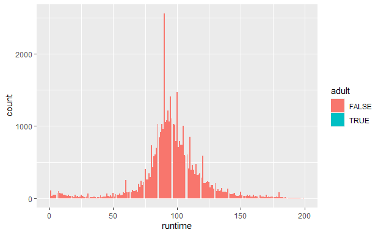

```r
ggplot(data = MetaData) + geom_bar(aes(x = runtime, fill = adult)) + xlim(0,200)
```

From the MetaData table alone we see that there are almost no cases where the film is classified as an adult film, and the data in turms of runtime presents itself in the shape of a bell-curve.